# Lab_02_QMSSG4062

Jianghanhan Li

3/21/2017

Find a complete social network, preferably one with at least some attributes about the nodes with it. (If you simply have a social network, but no real attributes, you will need to pick an additional network to compare that first one to.)

#### 1. Describe the social network(s) to me, in terms of how it was collected, what it represents and so forth. Also give me basic topography of the network: the nature of the ties; direction of ties; overall density; and if attributes are with the network, the distribution of the categories and variables of those attributes.

This Lazega network dataset comes from a network study of corporate law partnership that was carried out in a Northeastern US corporate law firm, referred to as SG&R, 1988-1991 in New England.

It includes (among others) measurements of networks among the 71 attorneys (partners and associates) of this firm, i.e. their strong-coworker network, advice network, friendship network, and indirect control networks. Various members’ attributes are also part of the dataset, including seniority, formal status, office in which they work, gender, lawschool attended, individual performance measurements (hours worked, fees brought in), attitudes concerning various management policy options, etc.

This dataset was used to identify social processes such as bounded solidarity, lateral control, quality control, knowledge sharing, balancing powers, regulation among peers. It’s directed and unweighted.

#### 2. Calculate degree centrality (in and out degree, too, if you have such data); closeness centrality; betweenness centrality; and eigenvector centrality. Correlate those measures of centrality. Highlight which nodes are most central and least central, along different dimensions.

```r
library(igraph)
# import lazega network data
test <- read.csv("~/Dropbox/Columbia_QMSS/Spring2017/Social_Network_Analysis/Data/Lazega_Friends.csv", header = TRUE, row.names = NULL, check.names = FALSE)
# turn the dataframe into a matrix
testm <- as.matrix(test)
# turn matrix into a sociomatrix
testmg <- graph.adjacency(testm, mode = "directed", weighted = NULL)
```

**Degree Centrality**

```r
V(testmg)$degree <- degree(testmg)
V(testmg)$degree
```

```
##  [1] 22 14 13 25 29 18  9 13 14 11 33 35 50 14 22 19 22 11 39 28 29 31 17
## [24] 44 15 54 31 44 24 36 36 26 25 23 30 18  6 20 32 31 47 31 25  6 19 17
## [47]  6 20 20 21 27 33  7 31 32 36 29 21 13 21  7 17 14 28 39 31 22 20 19
## [70] 17 21
```

**In Degree Centrality**

```r
V(testmg)$degree_in <- degree(testmg, mode = c("in"), loops = TRUE, normalized = FALSE)
V(testmg)$degree_in
```

```
##  [1] 15 14  5 16 16 13  5 10 10  9 14 13 34 10 16 14 15 10  9 17 18 19  8
## [24] 22  7 30 10 17 11 19 18 15  8 17 12 11  3 14 18 23 26  6 11  0  9 10
## [47]  1  3 11 11  4 20  3 17 10 16 17  9  4  9  4  7  2 20 14  5  6 10  7
## [70] 10  8
```

**Out Degree Centrality**

```r
V(testmg)$degree_out <- degree(testmg, mode = c("out"), loops = TRUE, normalized = FALSE)
V(testmg)$degree_out
```

```
##  [1]  7  0  8  9 13  5  4  3  4  2 19 22 16  4  6  5  7  1 30 11 11 12  9
## [24] 22  8 24 21 27 13 17 18 11 17  6 18  7  3  6 14  8 21 25 14  6 10  7
## [47]  5 17  9 10 23 13  4 14 22 20 12 12  9 12  3 10 12  8 25 26 16 10 12
## [70]  7 13
```

**Closeness Centrality**

```r
V(testmg)$closeness <- closeness(testmg, mode = c("all"))
V(testmg)$closeness
```

```
##  [1] 0.008333333 0.007751938 0.007812500 0.008547009 0.008196721
##  [6] 0.007874016 0.006896552 0.007518797 0.007751938 0.007575758
## [11] 0.008849558 0.009174312 0.009433962 0.007692308 0.008403361
## [16] 0.008264463 0.008403361 0.007462687 0.009174312 0.008695652
## [21] 0.008474576 0.008928571 0.008000000 0.009433962 0.007751938
## [26] 0.010526316 0.008849558 0.009174312 0.008264463 0.008771930
## [31] 0.008849558 0.008196721 0.008474576 0.008474576 0.008474576
## [36] 0.008064516 0.006944444 0.008000000 0.008264463 0.008333333
## [41] 0.009523810 0.008928571 0.008264463 0.006369427 0.007936508
## [46] 0.007751938 0.006802721 0.008196721 0.007874016 0.007936508
## [51] 0.008474576 0.008849558 0.006802721 0.008620690 0.008620690
## [56] 0.009009009 0.008264463 0.007936508 0.007142857 0.008064516
## [61] 0.006711409 0.007936508 0.007246377 0.008620690 0.009345794
## [66] 0.009009009 0.007751938 0.007812500 0.008000000 0.007936508
## [71] 0.008130081
```

**Betweenness Centrality**

```r
V(testmg)$betweenness <- betweenness(testmg, directed = F)
V(testmg)$betweenness
```

```
##  [1]  10.2564795  10.6839462   7.5886643  28.8130854  28.3403482
##  [6]   6.7282016   4.8924020   3.9468616   7.0189843  10.6563010
## [11]  64.2545231  47.8354768  63.2863265  13.6321867  50.6975669
## [16]  29.1413879  33.6402661   4.7186888  89.9778018  28.5413377
## [21]  15.8440153  49.6207057  19.6236650  72.4884204   9.2342041
## [26] 105.0367934  34.0628490  87.2240309  14.7830121  65.6946799
## [31]  47.4060036  19.5597929  37.5401920  35.1586375  33.7005165
## [36]  16.0675127   3.0352762   8.1423842  17.3182188  13.2935203
## [41]  60.4821048  47.0151173  14.8947576   1.7076748   8.6733333
## [46]  10.0497830   3.1965841  20.1058732   6.9581568  19.9978300
## [51]  35.3716385  20.6570804   0.7698842  25.3697299  26.7436879
## [56]  25.6141727  15.0954498  15.8755324   2.0407979  29.0864246
## [61]   1.5928138  13.8341369   2.4769419  77.7109881  51.3533575
## [66]  28.2002678   9.0868660   8.7269069   9.8568660  12.1377451
## [71]  12.8322301
```

**Correlation of Centrality.**

```r
dd <- data.frame(name = V(testmg)$name)
cb <- cbind(dd, V(testmg)$degree,  V(testmg)$degree_in, V(testmg)$degree_out, V(testmg)$closeness, V(testmg)$betweenness)
head(cb)
```

```
##   name V(testmg)$degree V(testmg)$degree_in V(testmg)$degree_out
## 1    1               22                  15                    7
## 2    2               14                  14                    0
## 3    3               13                   5                    8
## 4    4               25                  16                    9
## 5    5               29                  16                   13
## 6    6               18                  13                    5
##   V(testmg)$closeness V(testmg)$betweenness
## 1         0.008333333             10.256479
## 2         0.007751938             10.683946
## 3         0.007812500              7.588664
## 4         0.008547009             28.813085
## 5         0.008196721             28.340348
## 6         0.007874016              6.728202
```

From the above resutls, we see that `degree` centrality is closely related to `closenesss` centrality.

```r
cor(cb[, -1])
```

```
##                       V(testmg)$degree V(testmg)$degree_in
## V(testmg)$degree             1.0000000           0.7667575
## V(testmg)$degree_in          0.7667575           1.0000000
## V(testmg)$degree_out         0.8034713           0.2338947
## V(testmg)$closeness          0.9463725           0.7313624
## V(testmg)$betweenness        0.8253156           0.6044692
##                       V(testmg)$degree_out V(testmg)$closeness
## V(testmg)$degree                 0.8034713           0.9463725
## V(testmg)$degree_in              0.2338947           0.7313624
## V(testmg)$degree_out             1.0000000           0.7550744
## V(testmg)$closeness              0.7550744           1.0000000
## V(testmg)$betweenness            0.6894075           0.8273561
##                       V(testmg)$betweenness
## V(testmg)$degree                  0.8253156
## V(testmg)$degree_in               0.6044692
## V(testmg)$degree_out              0.6894075
## V(testmg)$closeness               0.8273561
## V(testmg)$betweenness             1.0000000
```

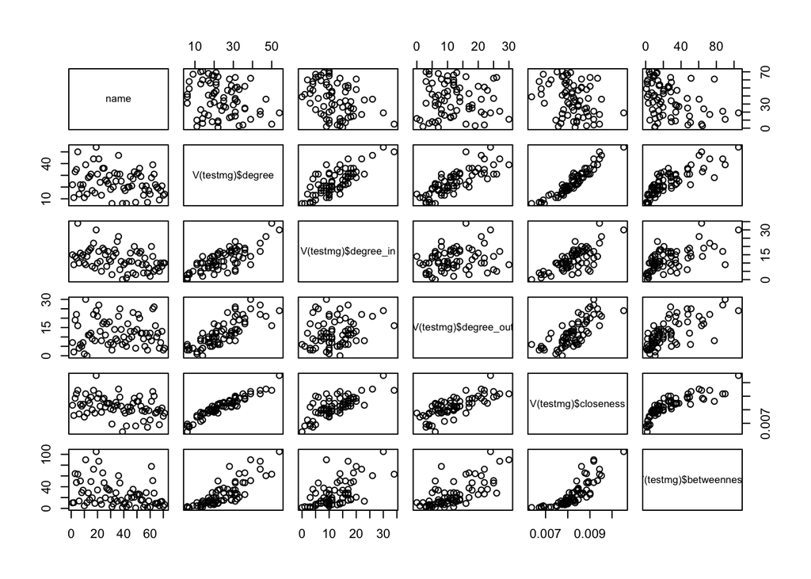

```r
plot(cb)
```

```r
order(cb$`V(testmg)$degree`, decreasing = T)[1]
```

```
## [1] 26
```

```r
order(cb$`V(testmg)$degree_in`, decreasing = T)[1]
```

```
## [1] 13
```

```r
order(cb$`V(testmg)$degree_out`, decreasing = T)[1]
```

```
## [1] 19
```

```r
order(cb$`V(testmg)$closeness`, decreasing = T)[1]
```

```
## [1] 26
```

```r
order(cb$`V(testmg)$betweenness`, decreasing = T)[1]
```

```
## [1] 26
```

```r
order(cb$`V(testmg)$degree`, decreasing = F)[1]
```

```
## [1] 37
```

```r
order(cb$`V(testmg)$degree_in`, decreasing = F)[1]
```

```
## [1] 44
```

```r
order(cb$`V(testmg)$degree_out`, decreasing = F)[1]
```

```
## [1] 2
```

```r
order(cb$`V(testmg)$closeness`, decreasing = F)[1]
```

```
## [1] 44
```

```r
order(cb$`V(testmg)$betweenness`, decreasing = F)[1]
```

```
## [1] 53
```

Overall, the node 26 is the most central, and the node 44 is the least central.

#### 3. Now, do 1 of the following, but not both: a. If you have a network with attribute data, then state some hypothesis about how an attribute may be related to some (or all of the) measures of centrality. Explains why you think these two variables should be related.

```r
# import lazega attribute data
testatt <- read.csv("~/Dropbox/Columbia_QMSS/Spring2017/Social_Network_Analysis/Data/Lazega_Attributes.csv")
```

```r
V(testmg)$name
```

```
##  [1] "1"  "2"  "3"  "4"  "5"  "6"  "7"  "8"  "9"  "10" "11" "12" "13" "14"
## [15] "15" "16" "17" "18" "19" "20" "21" "22" "23" "24" "25" "26" "27" "28"
## [29] "29" "30" "31" "32" "33" "34" "35" "36" "37" "38" "39" "40" "41" "42"
## [43] "43" "44" "45" "46" "47" "48" "49" "50" "51" "52" "53" "54" "55" "56"
## [57] "57" "58" "59" "60" "61" "62" "63" "64" "65" "66" "67" "68" "69" "70"
## [71] "71"
```

```r
V(testmg)$status <- testatt$status[match(V(testmg)$name, testatt$ID)]
V(testmg)$gender <- testatt$gender[match(V(testmg)$name, testatt$ID)]
V(testmg)$office <- testatt$office[match(V(testmg)$name, testatt$ID)]
V(testmg)$seniority <- testatt$seniority[match(V(testmg)$name, testatt$ID)]
V(testmg)$age <- testatt$age[match(V(testmg)$name, testatt$ID)]
V(testmg)$practice <- testatt$practice[match(V(testmg)$name, testatt$ID)]
V(testmg)$lawschool <- testatt$lawschool[match(V(testmg)$name, testatt$ID)]
```

```r
df <- cbind(cb, V(testmg)$status, V(testmg)$gender, V(testmg)$office, V(testmg)$seniority, V(testmg)$age, V(testmg)$practice, V(testmg)$lawschool)
summary(df)
```

```
##       name    V(testmg)$degree V(testmg)$degree_in V(testmg)$degree_out
##  1      : 1   Min.   : 6.00    Min.   : 0.00       Min.   : 0.00
##  10     : 1   1st Qu.:17.00    1st Qu.: 8.00       1st Qu.: 7.00
##  11     : 1   Median :22.00    Median :11.00       Median :11.00
##  12     : 1   Mean   :24.08    Mean   :12.04       Mean   :12.04
##  13     : 1   3rd Qu.:31.00    3rd Qu.:16.00       3rd Qu.:17.00
##  14     : 1   Max.   :54.00    Max.   :34.00       Max.   :30.00
##  (Other):65
##  V(testmg)$closeness V(testmg)$betweenness V(testmg)$status
##  Min.   :0.006369    Min.   :  0.7699      Min.   :1.000
##  1st Qu.:0.007812    1st Qu.:  9.1605      1st Qu.:1.000
##  Median :0.008264    Median : 17.3182      Median :1.000
##  Mean   :0.008224    Mean   : 26.2958      Mean   :1.493
##  3rd Qu.:0.008658    3rd Qu.: 34.6107      3rd Qu.:2.000
##  Max.   :0.010526    Max.   :105.0368      Max.   :2.000
##
##  V(testmg)$gender V(testmg)$office V(testmg)$seniority V(testmg)$age
##  Min.   :1.000    Min.   :1.00     Min.   : 1.00       Min.   :26.00
##  1st Qu.:1.000    1st Qu.:1.00     1st Qu.: 3.00       1st Qu.:33.50
##  Median :1.000    Median :1.00     Median : 7.00       Median :39.00
##  Mean   :1.254    Mean   :1.38     Mean   :10.56       Mean   :41.85
##  3rd Qu.:1.500    3rd Qu.:2.00     3rd Qu.:17.50       3rd Qu.:49.00
##  Max.   :2.000    Max.   :3.00     Max.   :32.00       Max.   :67.00
##
##  V(testmg)$practice V(testmg)$lawschool
##  Min.   :1.000      Min.   :1.000
##  1st Qu.:1.000      1st Qu.:2.000
##  Median :1.000      Median :2.000
##  Mean   :1.423      Mean   :2.183
##  3rd Qu.:2.000      3rd Qu.:3.000
##  Max.   :2.000      Max.   :3.000
##
```

```r
lm1 <- lm(V(testmg)$degree ~ V(testmg)$status + V(testmg)$gender + V(testmg)$office + V(testmg)$seniority + V(testmg)$age + V(testmg)$practice + V(testmg)$lawschool, df)
summary(lm1)
```

```
##
## Call:
## lm(formula = V(testmg)$degree ~ V(testmg)$status + V(testmg)$gender +
##     V(testmg)$office + V(testmg)$seniority + V(testmg)$age +
##     V(testmg)$practice + V(testmg)$lawschool, data = df)
##
## Residuals:
##      Min       1Q   Median       3Q      Max
## -15.6601  -5.9751  -0.6771   5.6648  22.6355
##
## Coefficients:
##                     Estimate Std. Error t value Pr(>|t|)
## (Intercept)         75.67508   11.33394   6.677 7.29e-09 ***
## V(testmg)$status    -8.27493    3.43080  -2.412  0.01879 *
## V(testmg)$gender    -2.89534    2.86412  -1.011  0.31593
## V(testmg)$office    -5.51585    1.93680  -2.848  0.00594 **
## V(testmg)$seniority -0.06658    0.23125  -0.288  0.77435
## V(testmg)$age       -0.37876    0.18134  -2.089  0.04078 *
## V(testmg)$practice  -6.30289    2.24366  -2.809  0.00661 **
## V(testmg)$lawschool -1.13371    1.58858  -0.714  0.47807
## ---
## Signif. codes:  0 '***' 0.001 '**' 0.01 '*' 0.05 '.' 0.1 ' ' 1
##
## Residual standard error: 9.179 on 63 degrees of freedom
## Multiple R-squared:  0.3421, Adjusted R-squared:  0.269
## F-statistic:  4.68 on 7 and 63 DF,  p-value: 0.0002852
```

From the above results, we see that `degree` centrality is significantly negatively related to `status`, `office`, `age` and `practice`.

#### 4. In either case, when you are done above, then considers alternate specifications of your variables and codings and decisions and models. What would you want to consider changing and why. If you can, report on what are the consequences of those changes?

I am going to recode `status` and `practice` for better interpretability.

```r
df$status_partner <- ifelse(df$`V(testmg)$status` == 1, 1, 0) # 1 partner, 0 associate
df$practice_litigation <- ifelse(df$`V(testmg)$practice` == 1, 1, 0) # 1 litigration practice, 0 corporate practice
```

Since some observations are not independent, which is an issue of using networks data to do node-level regression, I will play around with some methods to improve the results.

**Bootstrapping**

```r
lm2 <- lm(V(testmg)$degree ~ status_partner + practice_litigation + V(testmg)$age, df)
summary(lm2)
```

```
##
## Call:
## lm(formula = V(testmg)$degree ~ status_partner + practice_litigation +
##     V(testmg)$age, data = df)
##
## Residuals:
##      Min       1Q   Median       3Q      Max
## -19.0765  -6.7211  -0.4843   4.7048  24.6999
##
## Coefficients:
##                     Estimate Std. Error t value Pr(>|t|)
## (Intercept)          32.2588     5.5941   5.767 2.25e-07 ***
## status_partner        8.5434     2.8908   2.955  0.00431 **
## practice_litigation   7.1856     2.3096   3.111  0.00274 **
## V(testmg)$age        -0.3980     0.1425  -2.793  0.00679 **
## ---
## Signif. codes:  0 '***' 0.001 '**' 0.01 '*' 0.05 '.' 0.1 ' ' 1
##
## Residual standard error: 9.566 on 67 degrees of freedom
## Multiple R-squared:   0.24,  Adjusted R-squared:  0.206
## F-statistic: 7.054 on 3 and 67 DF,  p-value: 0.0003429
```

```r
library(simpleboot)
boot <- lm.boot(lm2, 50)
summary(boot)
```

```
## BOOTSTRAP OF LINEAR MODEL  (method = rows)
##
## Original Model Fit
## ------------------
## Call:
## lm(formula = V(testmg)$degree ~ status_partner + practice_litigation +
##     V(testmg)$age, data = df)
##
## Coefficients:
##         (Intercept)       status_partner  practice_litigation
##              32.259                8.543                7.186
##       V(testmg)$age
##              -0.398
##
## Bootstrap SD's:
##         (Intercept)       status_partner  practice_litigation
##          2.25343870           2.39566543           3.07202143
##       V(testmg)$age
##          0.02005376
```

**Permutation**

```r
library(lmPerm)
perm <- lmp(V(testmg)$degree ~ status_partner + practice_litigation + V(testmg)$age, df, perm = "Prob")
```

```
## [1] "Settings:  unique SS : numeric variables centered"
```

```r
summary(perm)
```

```
##
## Call:
## lmp(formula = V(testmg)$degree ~ status_partner + practice_litigation +
##     V(testmg)$age, data = df, perm = "Prob")
##
## Residuals:
##      Min       1Q   Median       3Q      Max
## -19.0765  -6.7211  -0.4843   4.7048  24.6999
##
## Coefficients:
##                     Estimate Iter Pr(Prob)
## status_partner         8.543 5000   0.0030 **
## practice_litigation    7.186 5000   0.0052 **
## V(testmg)$age         -0.398 5000   0.0026 **
## ---
## Signif. codes:  0 '***' 0.001 '**' 0.01 '*' 0.05 '.' 0.1 ' ' 1
##
## Residual standard error: 9.566 on 67 degrees of freedom
## Multiple R-Squared:  0.24,   Adjusted R-squared: 0.206
## F-statistic: 7.054 on 3 and 67 DF,  p-value: 0.0003429
```

#### 5. Lastly, give your best conclusion as to what you learned from your analysis. Did it make sense, given your initial expectations? Why? Why not?

From the above results, we see that being a partner (`status` = 1) increases one’s `degree` centrality by an average of 8.54 points than that of an assocaite, all else held equal. Also, practicing litigration law increases one’s `degree` centrality by an average of 7.18 points than practicing corporate law, all else held equal. `age` is negatively asssociated with `degree` centrality. For lawyer A and lawyer B, where A is 1 year older than B, lawyer A is said to have 0.398 points less of `degree` centrality than lawyer B, regardless of their `status` and `practice`.

Overall, it seems to suggest that being a young partner practing litigation law is more central at the law firm network, which makes some sense but it’s also very context-dependent.